# Day 1: instructor notes and demonstrations

Author

Masatoshi Katabuchi

For the instructor. Use with the exercise and the offline result sheet. These notes are excluded from the participant ZIP.

# Core exercise: purpose and model

Participants compare Survey A (2 survivors out of 5 seedlings) and Survey B (20 out of 50), predict a sample-size effect and explain posterior uncertainty. This uses the same binomial structure as the coin slides, now for seedling survival with a flat prior. The exercise assumes conditional independence and a common survival probability: $y \sim \operatorname{Binomial}(N,p)$, $p \sim \operatorname{Beta}(1,1)$. Hold that model, prior, grid and horizontal axis fixed in the comparison. Both observed proportions are 0.4; only the survey counts change.

Assume participants can run supplied R code and edit two assignments; do not require function writing or a derivation of the Beta posterior. Allow about 8 minutes for reading, prediction, editing and discussion, then 4 for explanation. If time is short, omit the optional prior comparison below.

`prior <- dbeta(...)` supplies the prior; `likelihood <- dbinom(...)` evaluates the likelihood with the counts fixed and p varying; multiplication and normalisation produce the grid posterior. The plotting lines only display it.

Survey A gives the continuous posterior Beta(3,4); Survey B gives Beta(21,31). Survey B has a narrower posterior because more observations make the likelihood more concentrated. The equal observed proportions do not imply equal information.

Participants copy the calculation into a new code chunk for the second survey, changing only y and N. Keep both plots visible. If copying a labelled Quarto chunk, give it a unique label or remove its label to avoid duplicate-label errors. Before class, rehearse creating the second chunk, changing the counts and rendering both figures in a fresh participant copy.

Example interpretation: “The two observed survival proportions are equal, but the larger survey gives less uncertainty about the survival probability.” Posterior means need not be identical. A narrower distribution does not mean that survival itself has become less variable or that the model assumptions have been verified.

The lecture plots continuous density; the exercise plots probability per grid point. Say only: “Compare the horizontal widths, not the heights.” Both exercise plots have the same horizontal axis and grid. Vertical scales adjust to avoid clipping when counts change; compare horizontal width, not raw displayed height. The y-axis is probability per grid point, not continuous density. A much larger N may require a finer grid to resolve the posterior width; use the modest survey sizes assigned during class rather than making grid resolution another core task.

`dbeta()` gives the prior density at each candidate p, and `dbinom()` evaluates the probability of the observed count for each candidate. Multiplying these values and normalising their sum produces a discrete grid approximation. The plotted heights are probabilities assigned to grid points, not continuous densities. Beta(1,1) gives equal prior weight across the grid.

If R is unavailable, use the 2/5 and 20/50 figures in `results.html`. Participants can still predict, compare and explain. Start individually; nearby help and discussion are optional. No fixed pairs or role changes are required, and no homework is required.

# Optional extension: change the prior

After the core task, suggest returning to `y <- 2` and `N <- 5` and replacing only the prior line with the following. Ask participants to predict the shift, rerun the whole chunk, then discuss what ecological evidence could support it. Keep the grid and horizontal axis fixed.

```r
prior <- dbeta(p, shape1 = 8, shape2 = 2)
```

The continuous posterior is Beta(10,5), with mean 10/15, compared with 3/7 under the flat prior. The posterior shifts towards higher survival probabilities. These priors are teaching contrasts, not general recommendations; a high-survival prior needs evidence from a comparable habitat and census period.

# Optional reference: posterior draws and summaries

The Day 1 core ends with the exercise debrief and recap. Posterior draws and their summaries have been removed from the Day 1 slide deck. Introduce MCMC and posterior summaries together on Day 2. The Stan and brms material below is instructor reference, not a required demonstration.

# Optional demonstration: Stan reads the same model

This demonstration returns to the starter 2/5 data, rather than participants’ own chosen counts. Follow the mapping from data to unknown survival probability and assumptions. Running these chunks is optional.

```r
library(tidyverse)
library(posterior)
library(bayesplot)
library(patchwork)
library(here)
source(here("R/functions.R"))
source(here("R/course_data.R"))
source(here("R/course_utils.R"))
source(here("R/course_visuals.R"))
theme_set(theme_bw(base_size = 14))
```

```stan
data {
  int<lower=0> N;             // number of seedlings
  int<lower=0, upper=N> y;    // number of survivors
  real<lower=0> a;            // prior: p ~ Beta(a, b)
  real<lower=0> b;
}

parameters {
  real<lower=0, upper=1> p;   // survival probability
}

model {
  // prior
  p ~ beta(a, b);
  // likelihood
  y ~ binomial(N, p);
}
```

```r
fit <- course_fit("day1_seedling")
draws <- fit$draws
fit$source
```

```
#> [1] "precomputed"
```

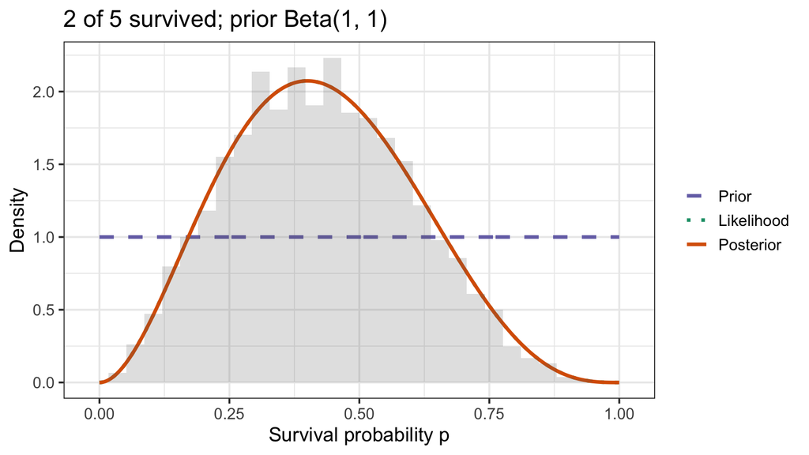

```r
plot_update(2, 5, 1, 1) +
  geom_histogram(
    data = as_tibble(draws),
    aes(x = p, y = after_stat(density)),
    inherit.aes = FALSE,
    bins = 30,
    fill = "grey40",
    alpha = .2
  )
```

The histogram approximates the exact posterior curve. Stan returns samples from a distribution. It does not return only a best value. The saved result uses the same 2/5 data and Beta(1,1) prior as our first plot.

## The same model in brms

brms writes Stan code from an R formula. Here we keep exactly the same model:

$$y\sim\operatorname{Binomial}(5,p),\qquad p\sim\operatorname{Beta}(1,1).$$

Read this as an alternative way to specify the model within the same demonstration, not an additional exercise. These chunks are not run when building the handout. The saved Stan result above remains the classroom fallback; it is not a brms fit.

```r
library(brms)
seedlings <- data.frame(y = 2L, N = 5L)
seedling_formula <- bf(y | trials(N) ~ 0 + Intercept)
seedling_family <- binomial(link = "identity")
seedling_prior <- set_prior("beta(1, 1)", class = "b", lb = 0, ub = 1)
```

| Part of the model | Stan | brms |
| --- | --- | --- |
| Observed counts | `N=5`, `y=2` | One row of `seedlings`; `trials(N)` supplies the number of seedlings |
| Unknown probability | `p`, bounded between 0 and 1 | `0 + Intercept` gives one coefficient, bounded by `lb=0, ub=1` |
| Observation model | `y ~ binomial(N, p)` | `binomial(link="identity")` makes that coefficient equal to $p$ |
| Prior | `p ~ beta(1, 1)` | The Beta prior on this coefficient, `class="b"` |

`0 + Intercept` treats the intercept as an ordinary coefficient so that the bounded prior applies to it. With the identity link, this coefficient is the probability itself. This bounded, intercept-only example matches our Stan model. The usual logit link instead models log-odds; a Normal prior there would give a different prior on $p$. Day 2 uses that logit formulation for a density-dependent probability.

**Optional instructor execution:** run the following only in a prepared environment with brms, CmdStan and a working C++ toolchain. It compiles a new model and runs new inference; participants do not need to run it or install anything. Prepare the result before class rather than waiting for compilation during the demonstration.

```r
fit_brms <- brm(
  formula = seedling_formula,
  data = seedlings,
  family = seedling_family,
  prior = seedling_prior,
  backend = "cmdstanr",
  seed = 20261021,
  chains = 4,
  cores = 2,
  iter = 2000,
  warmup = 1000,
  refresh = 0
)
brms_draws <- posterior::as_draws_df(fit_brms)
p_brms <- brms_draws$b_Intercept # identity link: this is p, not logit(p)
mean(p_brms)
quantile(p_brms, c(0.025, 0.975))

plot_update(2, 5, 1, 1) +
  geom_histogram(
    data = data.frame(p = p_brms),
    aes(x = p, y = after_stat(density)),
    inherit.aes = FALSE,
    bins = 30,
    fill = "grey40",
    alpha = .2
  )
```

The target posterior is again Beta(3,4): mean $3/7$ and the same exact interval as the first plot. The brms and handwritten Stan histograms should approximate the same distribution; individual draws and summaries need not match exactly. Before using a new fit, inspect chain traces, R-hat, bulk/tail ESS, divergences, treedepth and E-BFMI together. Model checking is still needed beyond computation.

For an optional look at the generated Stan code, without compilation or sampling:

```r
cat(make_stancode(
  seedling_formula,
  data = seedlings,
  family = seedling_family,
  prior = seedling_prior
))
```

References: brms documentation on [formulas](https://paulbuerkner.com/brms/reference/brmsformula.html), [bounded priors](https://paulbuerkner.com/brms/reference/set_prior.html), and [supported links](https://paulbuerkner.com/brms/reference/brmsfamily.html).

# Optional extension: a numerical summary

Do this after the core exercise or after class. The data and model stay fixed.

```r
draws <- course_fit("day1_seedling")$draws
summarise_update(2, 5, 1, 1)
```

```
#> # A tibble: 1 × 6
#>   data  prior        mle post_mean  q2_5 q97_5
#>   <chr> <chr>      <dbl>     <dbl> <dbl> <dbl>
#> 1 2/5   Beta(1, 1)   0.4     0.429 0.118 0.777
```

```r
mean(draws$p)
```

```
#> [1] 0.4251282
```

```r
quantile(draws$p, c(0.025, 0.975))
```

```
#>      2.5%     97.5%
#> 0.1182429 0.7644076
```

```r
mean(draws$p > 0.5)
```

```
#> [1] 0.3375
```

Interpret the interval in words. What does the last line estimate?

**TipSolution and instructor notes**

The interval describes uncertainty about the survival probability, conditional on the model, prior and data. The final line approximates the posterior probability that $p>0.5$. Small differences between the exact Beta calculations and saved Stan draws reflect Monte Carlo approximation. These summaries are optional today.